# 2 データ

**ヒント書き方ガイド：データ**

**何を書くか：** 分析に使用するデータの全体像を示す章です。データの出典・構造・基本統計量・可視化を通じて、読者がデータを十分に理解できるようにします。

**書き方のコツ：**

- **データ概要** では、取得元・期間・サンプル数・変数の一覧を明示します
- **基本統計量** は表形式で整理し、データの分布を把握できるようにします
- **可視化** は目的を明確にして（例：「時系列の傾向を確認する」）、図にキャプションと番号を付けます
- 前処理の手順はフロー図で示すと理解しやすくなります

**Quartoの機能：**

- R コードブロック `` ```{r} `` でデータ処理と可視化を実行できます
- `#| label: fig-xxx` と `#| fig-cap:` で図番号とキャプションを自動付与します
- `@fig-xxx` で本文中からクロスリファレンスできます
- `::: {.panel-tabset}` でタブ切替パネルを作成できます
- Mermaid 記法でフロー図を描けます

## 2.1 データの出典

表 2.1: データの出典

[output not shown]

## 2.2 データの準備

## 2.3 データ概要

本研究では、東京都内のシェアサイクル利用数と気象データを組み合わせた合成データセットを使用する。

表 2.2: データセットの概要

| 項目 | 内容 |
| --- | --- |
| 対象期間 | 2024年1月1日 〜 2024年12月31日（365日間） |
| 時間粒度 | 1時間単位 |
| レコード数 | 8,760件（365日 × 24時間） |
| 目的変数 | 1時間あたりの利用数（count） |
| 説明変数 | 気温、湿度、風速、降雨有無、曜日、時間帯 |

### 変数一覧

表 2.3: 変数一覧

| 変数名 | 型 | 説明 | 単位 |
| --- | --- | --- | --- |
| `date` | Date | 日付 | - |
| `hour` | integer | 時間帯（0–23） | 時 |
| `temperature` | numeric | 気温 | °C |
| `humidity` | numeric | 相対湿度 | % |
| `wind_speed` | numeric | 風速 | m/s |
| `is_rain` | integer | 降雨フラグ（0/1） | - |
| `count` | integer | 利用数（目的変数） | 台 |

## 2.4 基本統計量

表 2.4: 基本統計量

| 変数 | 平均 | 標準偏差 | 最小 | 中央値 | 最大 |
| --- | --- | --- | --- | --- | --- |
| temperature | 15.0 | 9.0 | -6.1 | 15.1 | 36.0 |
| humidity | 60.0 | 13.4 | 20.0 | 60.0 | 100.0 |
| wind_speed | 2.5 | 1.8 | 0.0 | 2.1 | 15.3 |
| count | 63.8 | 54.0 | 0.0 | 48.0 | 277.0 |

## 2.5 時系列の可視化

図 2.1 は日別の平均利用数の推移を示す。夏季に利用数が増加し、冬季に減少する季節パターンが確認できる。

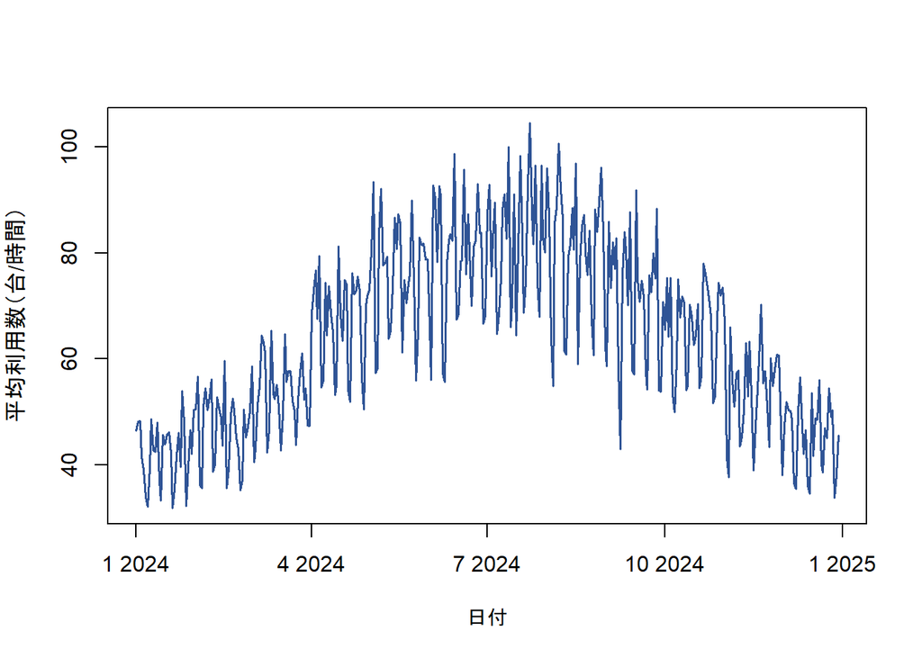

図 2.1: 日別平均利用数の推移

## 2.6 気象データとの関係

図 2.2 は気温と利用数の関係を示す散布図である。気温が高いほど利用数が増加する正の相関が認められる。

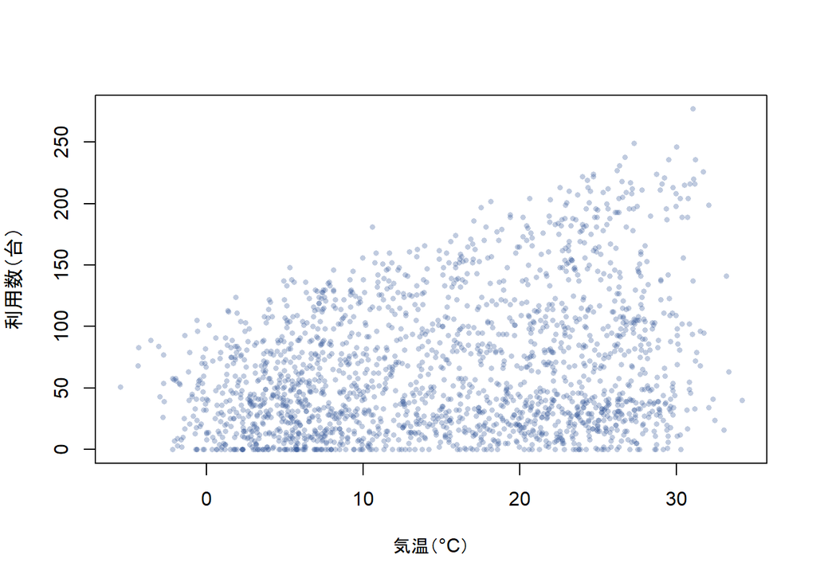

図 2.2: 気温と利用数の関係

## 2.7 曜日・時間帯パターン

**時間帯別**

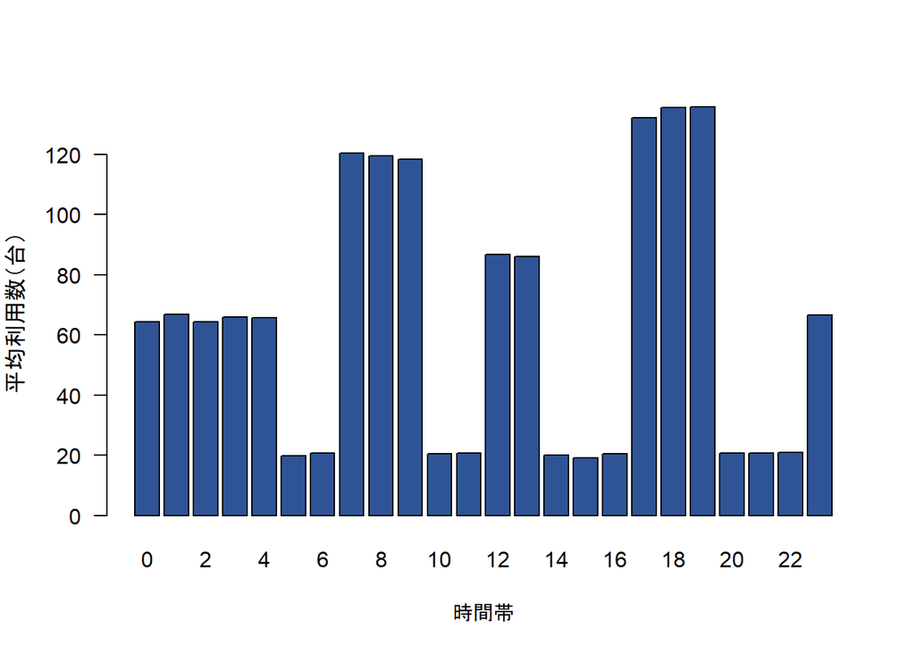

図 2.3: 時間帯別の平均利用数

**曜日別**

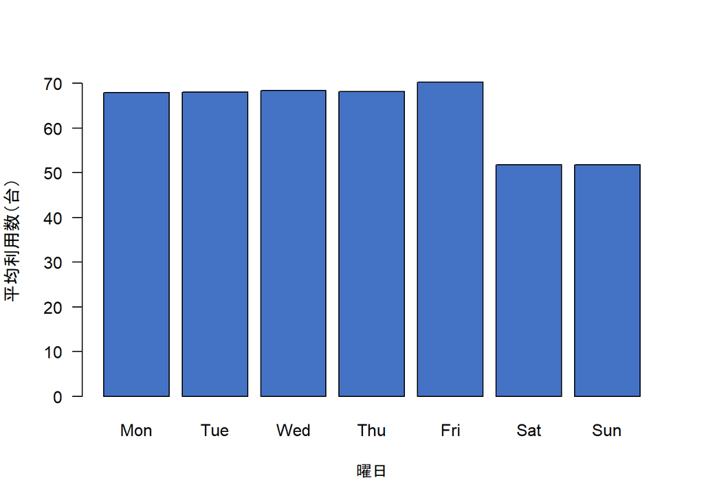

図 2.4: 曜日別の平均利用数

## 2.8 前処理パイプライン

[output not shown]